# When and Why TikTok Ads Capture Attention

## About this investigation

For this project I wanted to investigate what time of day I watched the most TikTok ads, and which ad topic I was the most interested in.

## When are Ads most frequent?

Using a line plot, I found that I tend to watch the most TikTok ads in the middle of the day starting at around 11am and peaking again at 2pm.

Fig. 1

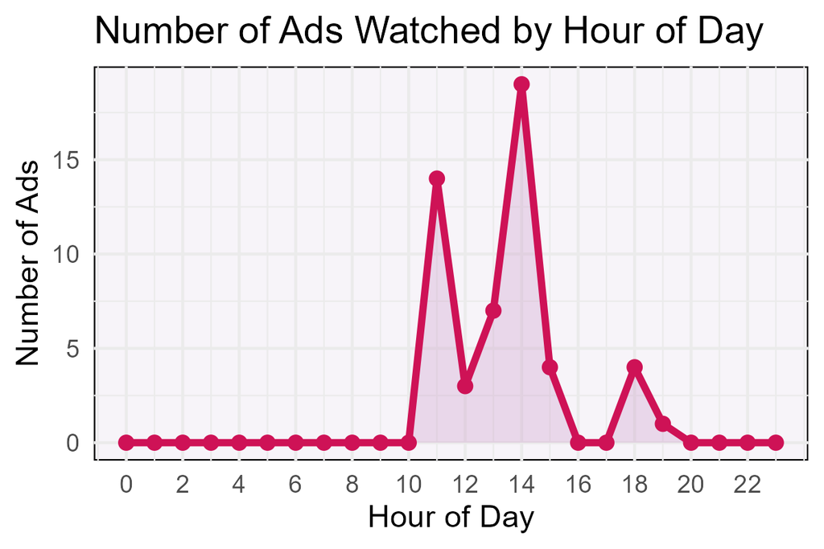

## Which Ad topics keep the most attention?

I used a bar chart to investigate which ads I watched the longest, and found that on average, I tend to watch beauty ads for the longest amount of time. Suggesting I might be more interested in beauty ads compared to other topics like technology.

Fig. 2

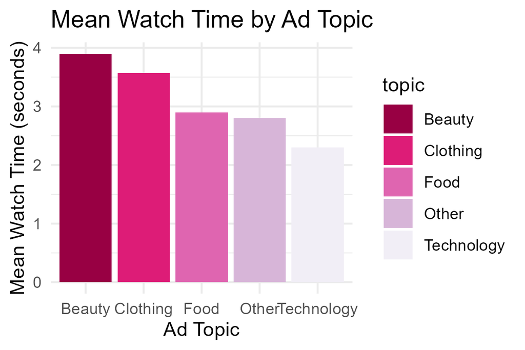

## Does interest affect watch time?

To support my investigation into what ads I find most interesting, I used a box plot to see whether my interest in an ad had a relationship with the amount of time I spent watching the ad. From this, I found that I tend to watch ads that I’m interested in longer than those I’m uninterested in.

Fig. 3

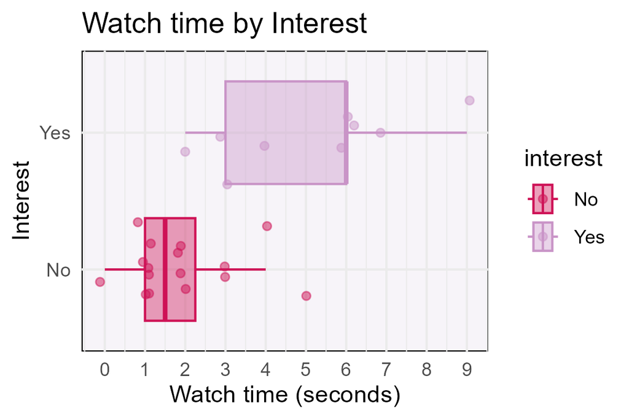

## Which topics are the most interesting?

To conclude my investigation I used a stacked bar chart to see which Ad topics had a higher proportion of interest compared to no interest. Through this I found that I was always interested in beauty ads and never interested in food ads.

Fig. 4

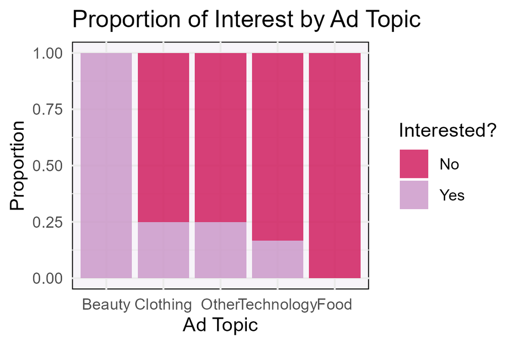

## Findings

Through my investigation of TikTok ad engagement, I found that I tend to watch the most ads midday around 11am and 2pm. I also discovered that I have the most interest in beauty ads compared to any other ad topic.